# The STAR-ting Point for STAR and EXOPLANET Exploration!

### Sourcing Fires by State Map

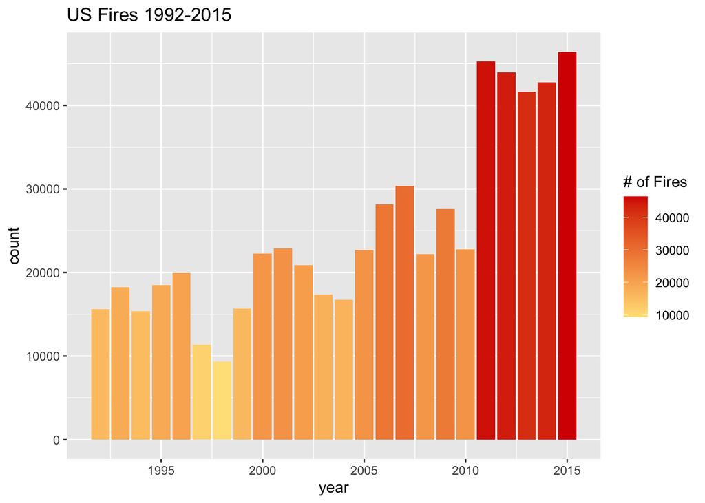

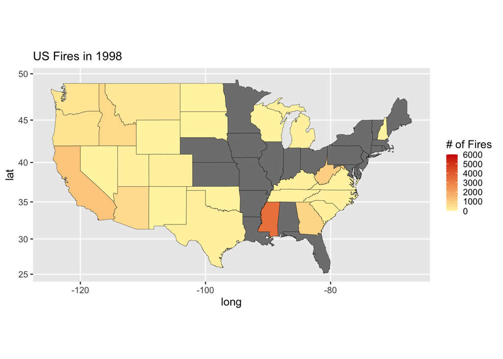

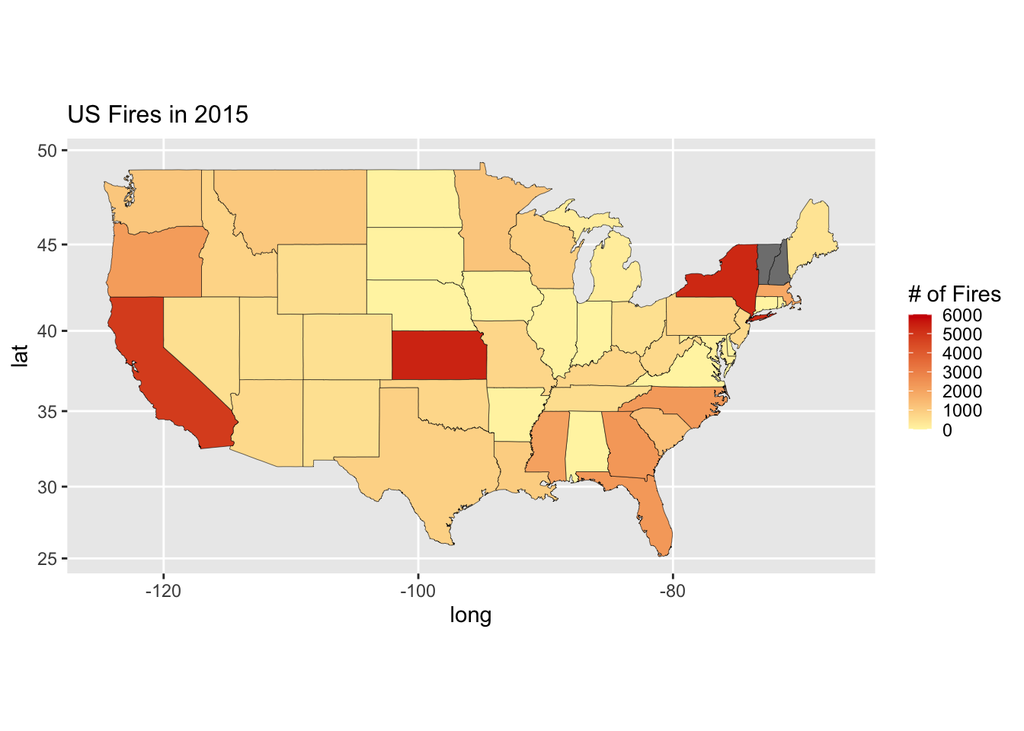

The bar graph (**US Fires 1992-2015**) is important in seeing the gradual increase in fires over the course of 23 years (1992-2015). It shows how dramatic the number of fires has jumped in just the previous five years from 2010 to 2015. The increase in fires from 1992 to 2010 revealed a more gradual increase, reflected in the shift from lighter oranges to darker yellows to darker oranges. But after 2010, that color shifted suddenly to a deep red. The choropleth map (**US Fires in 1998**) was included to give viewers a map to compare the more recent fires map (**US Fires in 2015**) to. The parts of the map shaded in gray represent states in which fire counts were not given. The map reveals the distribution of fires throughout the country. The distribution of fires was pretty uniform, besides in Mississippi. The second choropleth map (**US Fires in 2015**) was included to show how dramatic the increase in fires has been. Compared to the 1998 fire distribution map (**US Fires in 1998**), this map shows dramatic changes in certain states, especially *California, Kansas, and New York*. In the 1998 map, these states either had an unreported number of fires (*Kansas, New York*) or far fewer than in 2015 (*California*). This jump was not over the course of centuries or multiple decades, but over the course of just over 20 years. This can reveal how urgent of an issue fires has become in recent years and the importance of dealing with climate change.